# Background:

The data is for customers of the treadmill product(s) of a retail store called Cardio Good Fitness.

# Objective:

Explore the dataset to identify differences between customers of each product and explore relationships between the different attributes of customers. Approach it from any other line of questioning that you feel could be relevant for the business.

# Key questions to be answered:

- Understanding the structure of the data - Overview of the dataset shape, datatypes - Statistical summary and check for missing values
- Univariate Data Analysis - Analysis of spread and distribution of every feature in the dataset.
- Multivariate Data Analysis - Analysis of interaction between features, in the dataset
- Quality & Use of visualisations - The details in Visualization used.
- Conclusion and Recommendations - Conclude with the key insights/observations
- Well commented Python Code - Structure and flow - Well commented code
- Market share of each product and its reason.
- Study the preference of different product among various group of people.

# Dataset:

- Product - the model no. of the treadmill
- Age - in no of years, of the customer
- Gender - of the customer
- Education - in no. of years, of the customer
- Marital Status - of the customer
- Usage - Avg. # times the customer wants to use the treadmill every week
- Fitness - Self rated fitness score of the customer (5 - very fit, 1 - very unfit)
- Income - of the customer
- Miles- expected to run

### Import the necessary packages - pandas, numpy, seaborn, matplotlib.pyplot

```python
import warnings
warnings.filterwarnings('ignore')   # to avoid warnings

import numpy as np
import pandas as pd
import matplotlib.pyplot as plt
import seaborn as sns
sns.set(style="darkgrid") # sns.set_style('darkgrid')
sns.set(color_codes=True) # adds a nice background to the graphs
pd.set_option('display.float_format', lambda x: '%.2f' % x) # To supress numerical display in scientific notations
sns.set_palette("pastel") # Set the palette to the "pastel"
%matplotlib inline
```

### Read in the dataset

```python
cgfDF = pd.read_csv('CardioGoodFitness.csv')
```

### Check the shape of the dataset

```python
cgfDF.shape
```

```
(180, 9)
```

### Get all column names from dataframe

```python
cgfDF.columns
```

```
Index(['Product', 'Age', 'Gender', 'Education', 'MaritalStatus', 'Usage',
       'Fitness', 'Income', 'Miles'],
      dtype='object')
```

### Get all columns and its data types

```python
cgfDF.info()
```

```
<class 'pandas.core.frame.DataFrame'>
RangeIndex: 180 entries, 0 to 179
Data columns (total 9 columns):
 #   Column         Non-Null Count  Dtype
---  ------         --------------  -----
 0   Product        180 non-null    object
 1   Age            180 non-null    int64
 2   Gender         180 non-null    object
 3   Education      180 non-null    int64
 4   MaritalStatus  180 non-null    object
 5   Usage          180 non-null    int64
 6   Fitness        180 non-null    int64
 7   Income         180 non-null    int64
 8   Miles          180 non-null    int64
dtypes: int64(6), object(3)
memory usage: 12.8+ KB
```

### Inspect first few rows of the dataset

```python
cgfDF.head(10)
```

|  | Product | Age | Gender | Education | MaritalStatus | Usage | Fitness | Income | Miles |
| --- | --- | --- | --- | --- | --- | --- | --- | --- | --- |
| 0 | TM195 | 18 | Male | 14 | Single | 3 | 4 | 29562 | 112 |
| 1 | TM195 | 19 | Male | 15 | Single | 2 | 3 | 31836 | 75 |
| 2 | TM195 | 19 | Female | 14 | Partnered | 4 | 3 | 30699 | 66 |
| 3 | TM195 | 19 | Male | 12 | Single | 3 | 3 | 32973 | 85 |
| 4 | TM195 | 20 | Male | 13 | Partnered | 4 | 2 | 35247 | 47 |
| 5 | TM195 | 20 | Female | 14 | Partnered | 3 | 3 | 32973 | 66 |
| 6 | TM195 | 21 | Female | 14 | Partnered | 3 | 3 | 35247 | 75 |
| 7 | TM195 | 21 | Male | 13 | Single | 3 | 3 | 32973 | 85 |
| 8 | TM195 | 21 | Male | 15 | Single | 5 | 4 | 35247 | 141 |
| 9 | TM195 | 21 | Female | 15 | Partnered | 2 | 3 | 37521 | 85 |

### Find missing records for any columns

```python
cgfDF.isnull().sum()
```

```
Product          0
Age              0
Gender           0
Education        0
MaritalStatus    0
Usage            0
Fitness          0
Income           0
Miles            0
dtype: int64
```

Observation : No rows has missign records

### Check the datatype of the variables to make sure that the data is read in properly

```python
cgfDF.dtypes
```

```
Product          object
Age               int64
Gender           object
Education         int64
MaritalStatus    object
Usage             int64
Fitness           int64
Income            int64
Miles             int64
dtype: object
```

Observations:

1. Product, Gender and MaritalStatus is object data type
2. Education is integer type currently. Since Education is a categorical variable so convert it to category data data type.
3. All the other variables are numerical and there for their python data types is int64.

```python
# Convert number of year of Education into category
cgfDF.Education = cgfDF.Education.astype('category');
cgfDF.dtypes
```

```
Product            object
Age                 int64
Gender             object
Education        category
MaritalStatus      object
Usage               int64
Fitness             int64
Income              int64
Miles               int64
dtype: object
```

### Analyse and inspect the quantitative variables in the dataset

```python
cgfDF.describe().T
```

|  | count | mean | std | min | 25% | 50% | 75% | max |
| --- | --- | --- | --- | --- | --- | --- | --- | --- |
| Age | 180.00 | 28.79 | 6.94 | 18.00 | 24.00 | 26.00 | 33.00 | 50.00 |
| Usage | 180.00 | 3.46 | 1.08 | 2.00 | 3.00 | 3.00 | 4.00 | 7.00 |
| Fitness | 180.00 | 3.31 | 0.96 | 1.00 | 3.00 | 3.00 | 4.00 | 5.00 |
| Income | 180.00 | 53719.58 | 16506.68 | 29562.00 | 44058.75 | 50596.50 | 58668.00 | 104581.00 |
| Miles | 180.00 | 103.19 | 51.86 | 21.00 | 66.00 | 94.00 | 114.75 | 360.00 |

```python
cgfDF.describe(include=['object', 'category'])
```

|  | Product | Gender | Education | MaritalStatus |
| --- | --- | --- | --- | --- |
| count | 180 | 180 | 180 | 180 |
| unique | 3 | 2 | 8 | 2 |
| top | TM195 | Male | 16 | Partnered |
| freq | 80 | 104 | 85 | 107 |

Observation

### Finding reason for large difference between mean and 50% percentile of Miles attribute

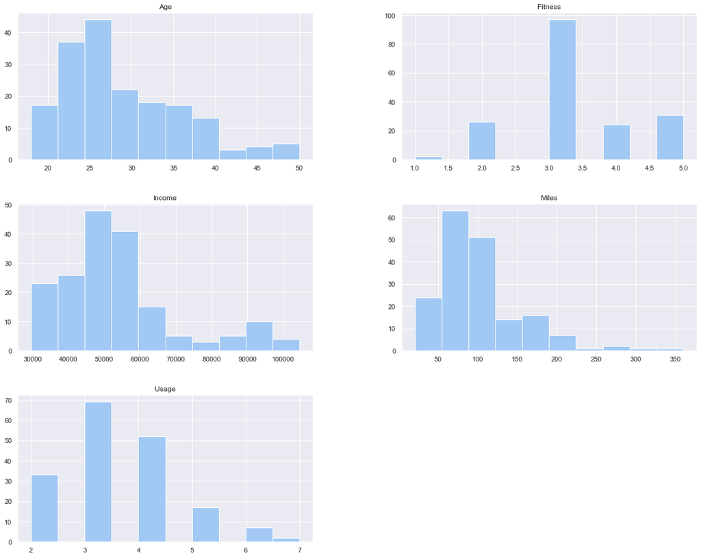

```python
cgfDF.hist(figsize=(20,16), grid=True);
```

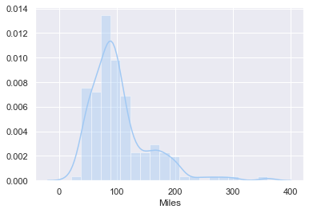

```python
sns.distplot(cgfDF.Miles);
```

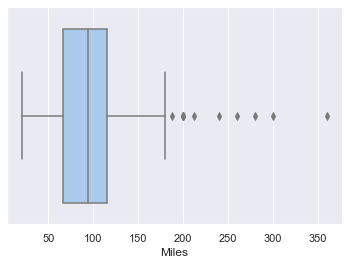

```python
sns.boxplot(cgfDF.Miles);
```

Observation:

1) For Miles, distribution and Box blot , 8 records are outlier which explains why mean is not close to the 50% percentile.

```python
# Create a additional column in dataframe for average miles per usage.
# This will give better picture of avarage use of eacg type of product
cgfDF['MilesPerUsage'] = cgfDF['Miles']/cgfDF['Usage']
```

### Looking at the relationship between numerical variables using pair plots , correlation plots and heat map

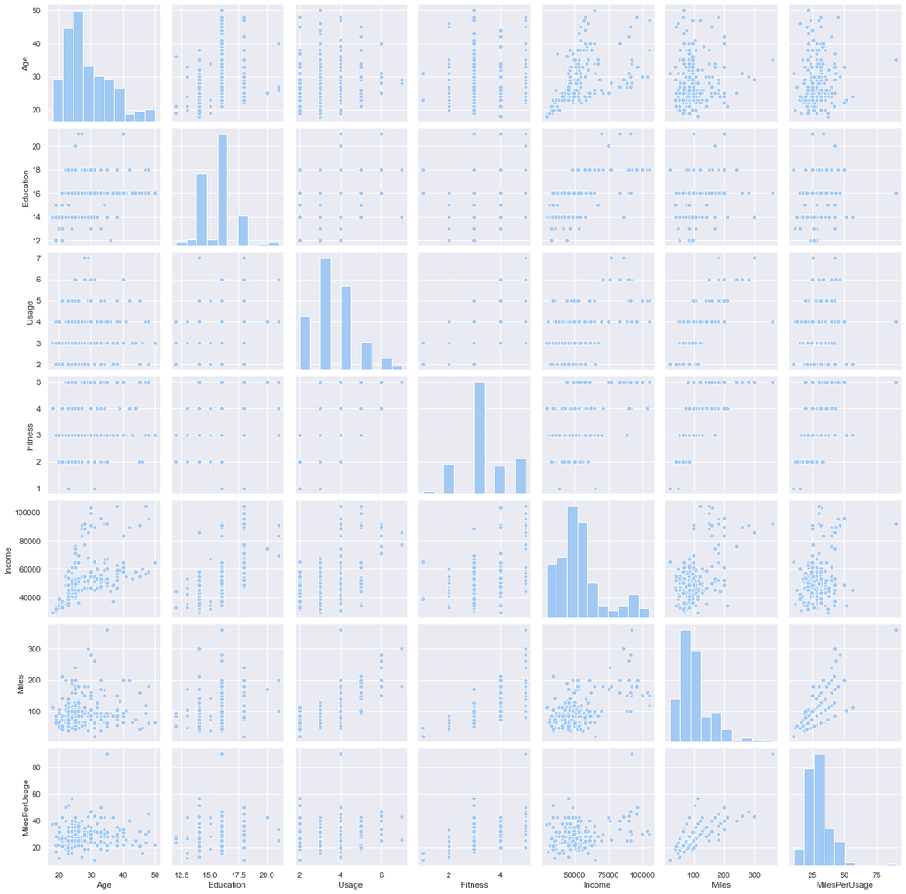

```python
sns.pairplot(cgfDF);
```

```python
cgfDFCorr = cgfDF.corr()
cgfDFCorr
```

|  | Age | Usage | Fitness | Income | Miles | MilesPerUsage |
| --- | --- | --- | --- | --- | --- | --- |
| Age | 1.00 | 0.02 | 0.06 | 0.51 | 0.04 | 0.01 |
| Usage | 0.02 | 1.00 | 0.67 | 0.52 | 0.76 | 0.16 |
| Fitness | 0.06 | 0.67 | 1.00 | 0.54 | 0.79 | 0.56 |
| Income | 0.51 | 0.52 | 0.54 | 1.00 | 0.54 | 0.27 |
| Miles | 0.04 | 0.76 | 0.79 | 0.54 | 1.00 | 0.73 |
| MilesPerUsage | 0.01 | 0.16 | 0.56 | 0.27 | 0.73 | 1.00 |

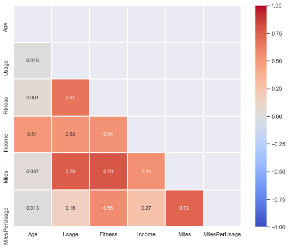

```python
# Below steps  and configuration will create heat map for lower diagonal half only , as we know lower and
# upper half half contains same value but with differnt order of axis.
cgf_mask = np.zeros_like(cgfDFCorr, dtype=np.bool)
cgf_mask[np.triu_indices_from(cgf_mask)] = True
fig, ax = plt.subplots(figsize=(10, 8))
sns.heatmap(cgfDFCorr,  annot=True, mask=cgf_mask, cmap= "coolwarm", vmax=1, vmin=-1, center=-0,
                 linewidths=1, cbar_kws={"shrink": 1});
```

Observation:

2) Income & usage, income & Fitness and miles & income needs further investigation.

3) Usage & age, fitness & age , miles and age are weakly coorelated.

### Finding the market share of each type of products through pie chart and count plot

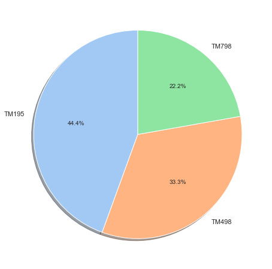

```python
# Steps to set required parameter to draw pie chart
# Step 1: Get all types of Product into a list
prod_labels = list(cgfDF.Product.unique())

# Step 2: Get number of each type of product.
def getProductsNum(prod_labels):
    prodCount = []
    for i, label in enumerate(prod_labels):
        prodCount.append(cgfDF[cgfDF['Product'] == label]['Product'].count())
    return prodCount

# Step3: Call the matplot lib Pie method to draw the pie chart. It will take data  and labels derived in above steps
# Configuring appropriate setting for matplot lib pie chart
fig, ax = plt.subplots(figsize=(10, 8))
ax.pie(getProductsNum(prod_labels), labels=prod_labels, autopct='%1.1f%%',shadow=True, startangle=90);
```

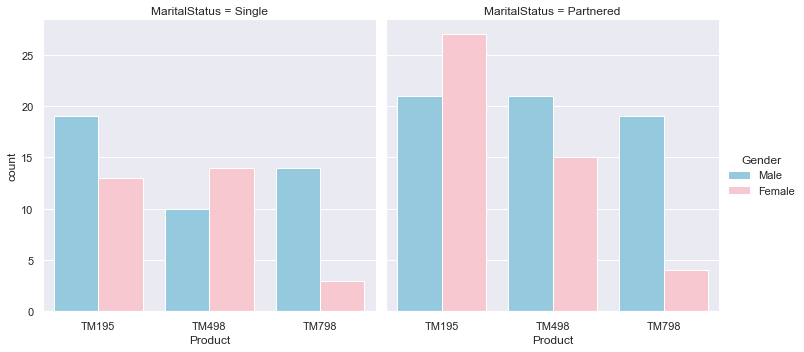

```python
sns.catplot(x="Product",
               hue="Gender",
               col="MaritalStatus",
               data=cgfDF,
               kind="count",
               palette=sns.color_palette(['skyblue', 'pink']));
```

```python
pd.crosstab(cgfDF.Product, [cgfDF.MaritalStatus, cgfDF.Gender], margins=True, margins_name="Total")
```

| MaritalStatus Gender Product | Partnered Female | Partnered Male | Single Female | Single Male | Total |
| --- | --- | --- | --- | --- | --- |
| TM195 | 27 | 21 | 13 | 19 | 80 |
| TM498 | 15 | 21 | 14 | 10 | 60 |
| TM798 | 4 | 19 | 3 | 14 | 40 |
| Total | 46 | 61 | 30 | 43 | 180 |

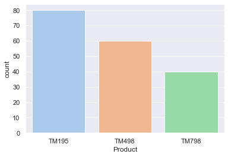

```python
# Confirm the market share of pie chart through countplot now
sns.countplot(data = cgfDF, x='Product');
```

Observation:

1) Largest market share are in this order TM195, TM498 and TM798. Lets further investigate to find out details like reason and preference for these products by customer.

2) For TM798, irrespective MartialStatus Male choose product more than female.

3) For TM195, Choice of this product has doubled for single female to Partnerd Female against the slight increase in male choice.

4) For TM498, Choice of this product has doubled for single male to Partnerd male against the slight increase in female choice

### Study the usage trend and prefernce for Product for age, income group, gender , fitness and by martial status.

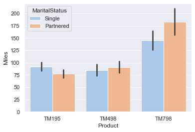

```python
sns.barplot(x='Product', y='Miles' ,  hue=cgfDF['MaritalStatus'], data=cgfDF);
```

Observation: Average miles recorded on TM798 is most, irrespective of any martial status.

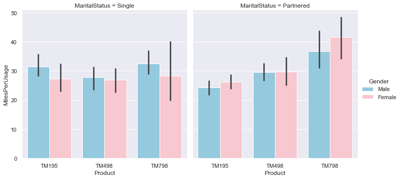

```python
sns.catplot(x="Product",
               y = "MilesPerUsage",
               hue="Gender",
               col="MaritalStatus",
               data=cgfDF,
               kind="bar",
               palette=sns.color_palette(['skyblue', 'pink']));
```

Observation:

1) Single male runs more MilesPerUsage and partnered female runs more MilePerUsage.

2) For TM498, MilesPerusage are almost equal for both gender for any martialStatus

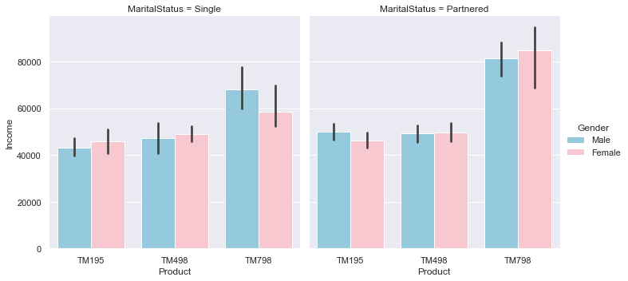

```python
sns.catplot(x="Product",
            y="Income",
            hue="Gender",
            col='MaritalStatus',
            data=cgfDF,kind='bar',
            palette=sns.color_palette(['skyblue', 'pink']));
```

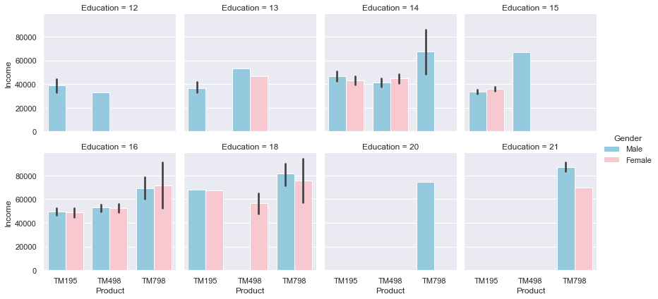

```python
sns.catplot(x="Product",
            y="Income",
            hue="Gender",
            col='Education',
            data=cgfDF,kind='bar',
            height=3,col_wrap = 4,
            palette=sns.color_palette(['skyblue', 'pink']));
```

Observation:

1) People with high income prefers TM798.

2) People with Higher education has higher income.

3) For Education level 12, 13 no one is using TM798

4) For Education level 20, 21 , No one is using TM195 and TM498

5) For TM498, average income is almost equal for both geneders in any martialStatus

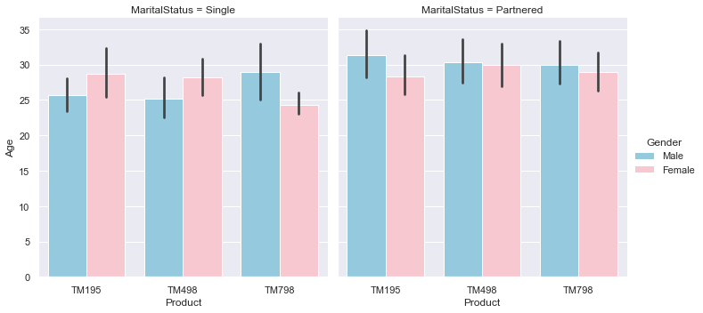

```python
sns.catplot(x="Product",
            y="Age",
            hue="Gender",
            col='MaritalStatus',
            data=cgfDF,kind='bar',
            palette=sns.color_palette(['skyblue', 'pink']));
```

#### Observation:

1) Age and marital status for any gender doesn't give any conclusive decision for prefernce one product over other.

2) For TM498, Partnered Male/Female like it equally for any age group.

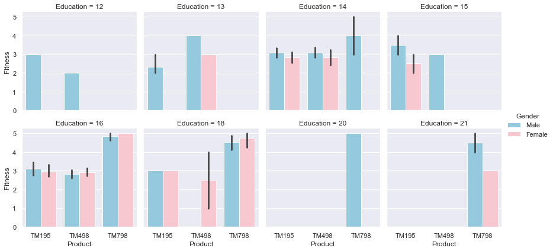

```python
sns.catplot(x="Product",
            y="Fitness",
            hue="Gender",
            col='Education',
            data=cgfDF,
            kind='bar',
            height=3,col_wrap = 4,
            palette=sns.color_palette(['skyblue', 'pink']));
```

Observation: People with high education background has high fitness rating and they are using TM798

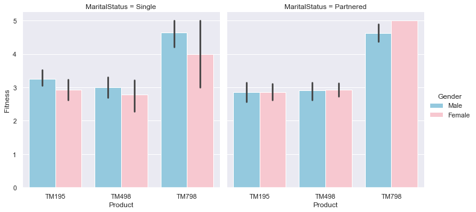

```python
sns.catplot(x="Product",
            y="Fitness",
            hue="Gender",
            col='MaritalStatus',
            data=cgfDF,
            kind='bar',
            palette=sns.color_palette(['skyblue', 'pink']));
```

Observation: Fitness rating is better for people who are using TM798

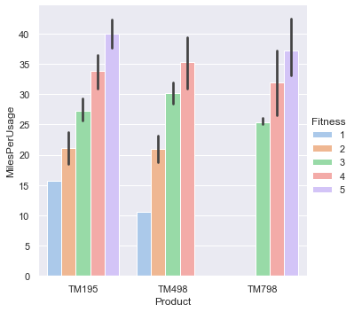

```python
sns.catplot(x='Product', y='MilesPerUsage', hue='Fitness', data=cgfDF, kind='bar');
```

### Conclusion:

1) For TM195, Choice of this product is doubled for single female to Partnerd Female against the slight increase in male choice.

3) Only TM195 has fitness rating from all rating categories(1 to 5)) also its MilesPerUsage are better than TM798 for corresponding rating category.

4) People with high income prefers TM798. Also people with high education background has high fitness rating and they prefer TM798. There is strong coorelation between High income and high education year.

5) For TM798, irrespective MartialStatus Male choose product more than female.

6) TM798 are rating themselves higher even if their Miles Per Usage are less than other two products. This enhanced rating might be due to better user experience of product. Newer generation of product will be costlier than previous generation Which then becomes affordable as income grows and income is also dependent on Higher education and age.

7) For TM498, Partnered Male/Female like it equally for any age group.

8) For TM498, No one has rated it for fitness level 5.

9) For TM498, MilesPerusage are almost equal for both gender for any martialStatus

10) For TM498, Choice of this product is doubled for single male to Partnerd male against the slight increase in female choice

11) For TM498, average income is almost equal for both geneders in any martialStatus